# Assessment 0 Documentation

Billy Ryan

2025-10-06

## Read the data

Before any data analysis can begin, we must first import out data set and required libraries. The data set in question can be found at https://www.kaggle.com/datasets/ealaxi/paysim1. It is quite a large data set so it may take some time to download and load into R.

```r
pkgs <- c("tidyverse","ggplot2","plyr","corrplot","dplyr","magrittr","RColorBrewer", "data.table")

for(p in pkgs){
    if (!require(p,character.only=TRUE)) install.packages(p)
}
library(tidyverse)
library(ggplot2)
library(plyr)
library(corrplot)
library(dplyr)
library(magrittr)
library(RColorBrewer)
library(data.table)
```

Now we load the data

```r
# R has timeout set to 60 by default, which is likely not enough time to download and import such a big data set hence we increase it here
options(timeout = 1000)

# If not data set is not already downloaded, fetch it
if (!file.exists("PS_20174392719_1491204439457_log.csv")) {
  message("Downloading large dataset, this may take a few minutes.")
  download.file("https://media.githubusercontent.com/media/railtonjamesl-collab/ds-project/refs/heads/main/dataset/PS_20174392719_1491204439457_log.csv", "PS_20174392719_1491204439457_log.csv", mode = "wb")
}

# And now we are able to load the data
dataset <- fread("PS_20174392719_1491204439457_log.csv")
```

Observe the data at hand briefly to make sure there is nothing strange going on i.e. missing variables.

```r
head(dataset)
```

```
##     step     type   amount    nameOrig oldbalanceOrg newbalanceOrig    nameDest
##    <int>   <char>    <num>      <char>         <num>          <num>      <char>
## 1:     1  PAYMENT  9839.64 C1231006815        170136      160296.36 M1979787155
## 2:     1  PAYMENT  1864.28 C1666544295         21249       19384.72 M2044282225
## 3:     1 TRANSFER   181.00 C1305486145           181           0.00  C553264065
## 4:     1 CASH_OUT   181.00  C840083671           181           0.00   C38997010
## 5:     1  PAYMENT 11668.14 C2048537720         41554       29885.86 M1230701703
## 6:     1  PAYMENT  7817.71   C90045638         53860       46042.29  M573487274
##    oldbalanceDest newbalanceDest isFraud isFlaggedFraud
##             <num>          <num>   <int>          <int>
## 1:              0              0       0              0
## 2:              0              0       0              0
## 3:              0              0       1              0
## 4:          21182              0       1              0
## 5:              0              0       0              0
## 6:              0              0       0              0
```

```r
summary(dataset)
```

```
##       step           type               amount           nameOrig
##  Min.   :  1.0   Length:6362620     Min.   :       0   Length:6362620
##  1st Qu.:156.0   Class :character   1st Qu.:   13390   Class :character
##  Median :239.0   Mode  :character   Median :   74872   Mode  :character
##  Mean   :243.4                      Mean   :  179862
##  3rd Qu.:335.0                      3rd Qu.:  208721
##  Max.   :743.0                      Max.   :92445517
##  oldbalanceOrg      newbalanceOrig       nameDest         oldbalanceDest
##  Min.   :       0   Min.   :       0   Length:6362620     Min.   :        0
##  1st Qu.:       0   1st Qu.:       0   Class :character   1st Qu.:        0
##  Median :   14208   Median :       0   Mode  :character   Median :   132706
##  Mean   :  833883   Mean   :  855114                      Mean   :  1100702
##  3rd Qu.:  107315   3rd Qu.:  144258                      3rd Qu.:   943037
##  Max.   :59585040   Max.   :49585040                      Max.   :356015889
##  newbalanceDest         isFraud         isFlaggedFraud
##  Min.   :        0   Min.   :0.000000   Min.   :0.0e+00
##  1st Qu.:        0   1st Qu.:0.000000   1st Qu.:0.0e+00
##  Median :   214661   Median :0.000000   Median :0.0e+00
##  Mean   :  1224996   Mean   :0.001291   Mean   :2.5e-06
##  3rd Qu.:  1111909   3rd Qu.:0.000000   3rd Qu.:0.0e+00
##  Max.   :356179279   Max.   :1.000000   Max.   :1.0e+00
```

```r
dim(dataset)
```

```
## [1] 6362620      11
```

```r
sum(is.na(dataset))
```

```
## [1] 0
```

Everything looks reasonable, with some outliers being visible, specifically in the numerical variables. We will now proceed with some EDA to try and understand the data more astutely.

One of our first questions when looking at the data is how many transactions are fraudulent?

```r
table(dataset$isFraud)
```

```
##
##       0       1
## 6354407    8213
```

```r
table(dataset$isFraud)/length(dataset$isFraud)
```

```
##
##          0          1
## 0.99870918 0.00129082
```

The “0” represents non-fraudulent transactions and “1” fraudulent transactions. Here we see that roughly 99.87% of all transactions are non-fraudulent and 0.13% of transactions are fraudulent. Since we are asked to use visualisations in this assessment, we will produce many different types of plots to better understand the data at hand:

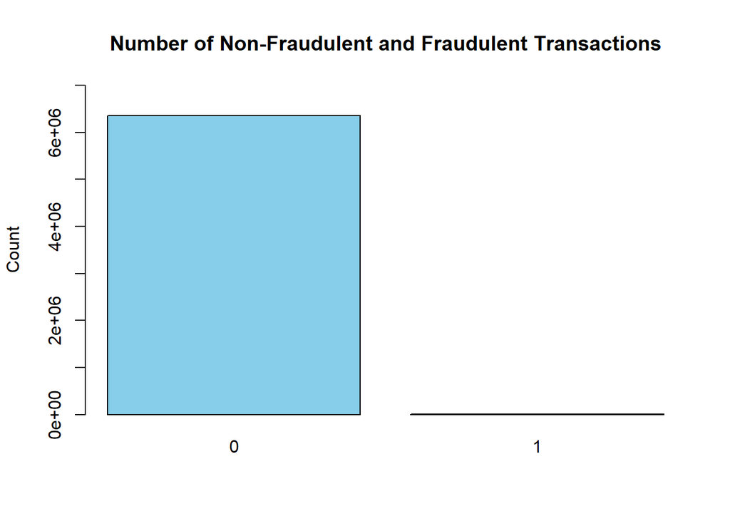

```r
barplot(table(dataset$isFraud), main="Number of Non-Fraudulent and Fraudulent Transactions", ylab="Count", ylim=c(0,7000000), col = c("skyblue"))
```

Using this plot and the beforehand calculation, we can easily determine that the vast majority of transactions are non-fraudulent.

It might be of interest to see how the transactions are spaced out by type.

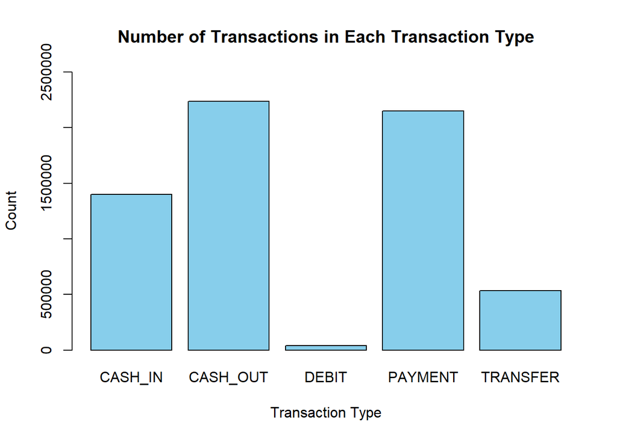

```r
barplot(table(dataset$type),
        main="Number of Transactions in Each Transaction Type",
        xlab="Transaction Type",
        ylab="Count",
        ylim=c(0,2500000),
        col=c("skyblue"))
```

We may also with to visualise this using a pie chart, as it may be easier for comparisons

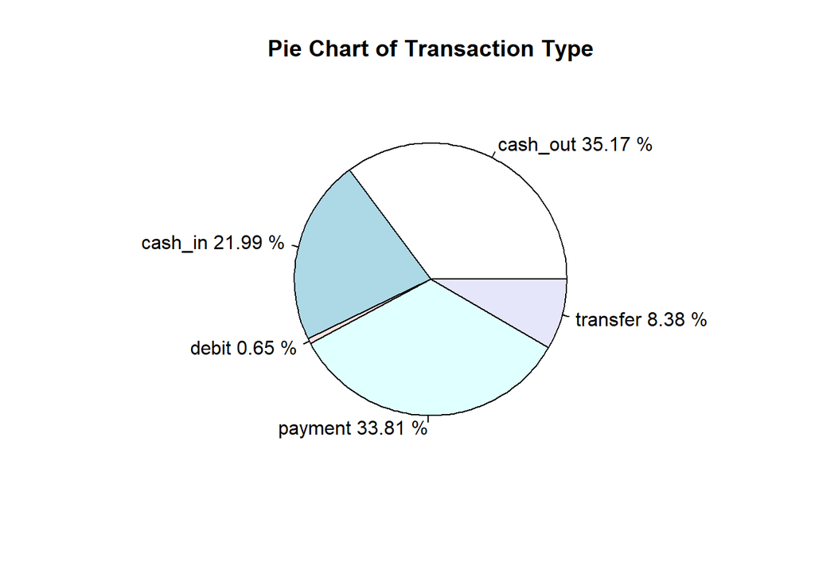

```r
info <- c(sum(dataset$type=="CASH_OUT"),sum(dataset$type=="CASH_IN"),sum(dataset$type=="DEBIT"),sum(dataset$type=="PAYMENT"),sum(dataset$type=="TRANSFER"))
names <- c("cash_out", "cash_in", "debit", "payment", "transfer")
pct <- round(info/sum(info)*100, digits=2)
names <- paste(names, pct, "%")
pie(info,labels = names, main = "Pie Chart of Transaction Type")
```

This tells us that generally most transactions are either payments and cash related. We can make these graphs more useful by only considering fraudulent transactions, giving us an opportunity to make better inferences.

```r
table(factor(dataset$type[dataset$isFraud == 1],levels = unique(dataset$type)))
```

```
##
##  PAYMENT TRANSFER CASH_OUT    DEBIT  CASH_IN
##        0     4097     4116        0        0
```

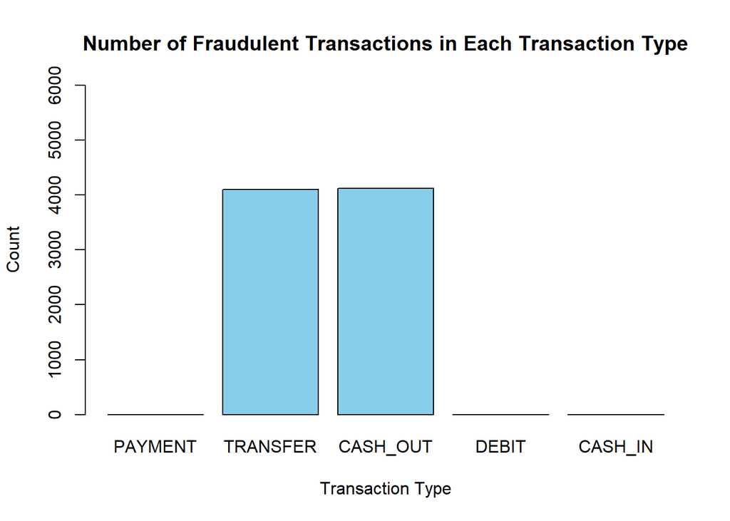

```r
barplot(table(factor(dataset$type[dataset$isFraud == 1],levels = unique(dataset$type))),
        main="Number of Fraudulent Transactions in Each Transaction Type",
        xlab="Transaction Type",
        ylab="Count",
        ylim=c(0,6000),
        col=c("skyblue"))
```

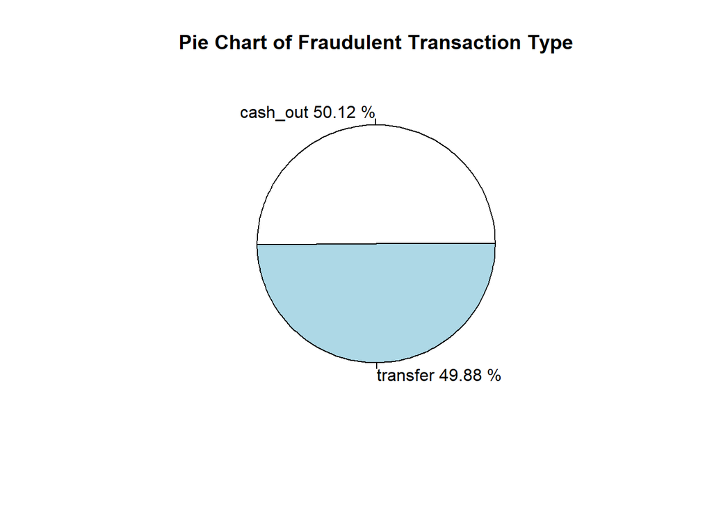

```r
info <- c(sum(dataset$type[dataset$isFraud==1]=="CASH_OUT"),sum(dataset$type[dataset$isFraud==1]=="TRANSFER"))
names <- c("cash_out", "transfer")
pct <- round((info/sum(info)*100),digits=2)
names <- paste(names, pct, "%")
pie(info,labels = names, main = "Pie Chart of Fraudulent Transaction Type")
```

As we see, the categories of PAYMENT, DEBIT and CASH_IN have no fraudulent transactions, whilst the remaining categories of TRANSFER and CASH_OUT have roughly a 50/50 split of 4000 transactions each that are fraudulent. This is where expert analysis may be of use, as it will allow us to deduce the usefulness of this specific data.

We will now compute histograms to help us compare transactions and fraudulent transactions.

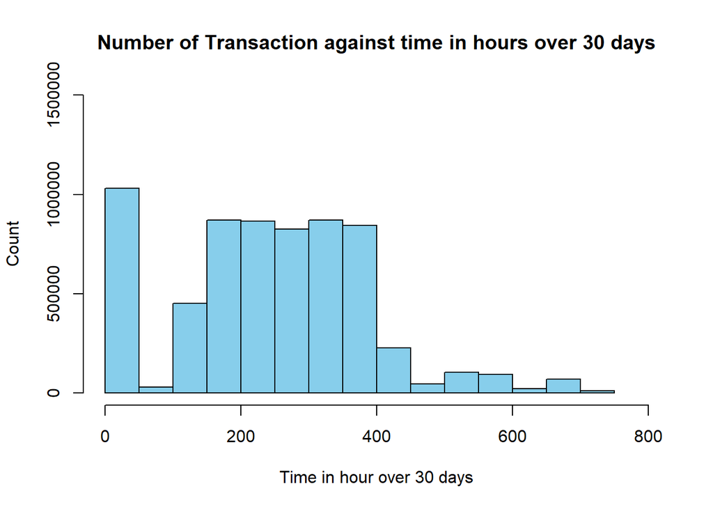

```r
hist(dataset$step,
     main="Number of Transaction against time in hours over 30 days",
     xlab="Time in hour over 30 days",
     ylab="Count",
     ylim=c(0,1500000),
     xlim=c(0,800),
     col=c("skyblue"))
```

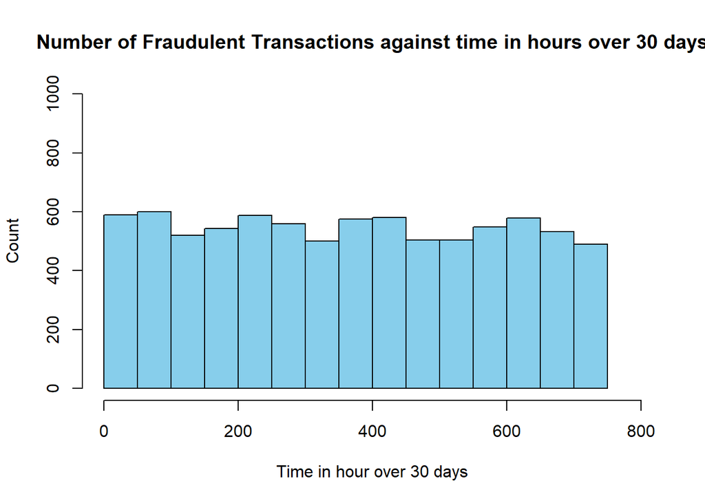

```r
hist(dataset$step[dataset$isFraud==1],
     main="Number of Fraudulent Transactions against time in hours over 30 days",
     xlab="Time in hour over 30 days",
     ylab="Count",
     ylim=c(0,1000),
     xlim=c(0,800),
     col=c("skyblue"))
```

We can see the difference in all transactions versus only fraudulent transactions, that being the fraudulent ones are much more uniformly distributed. We may find it interesting to see when transactions occur depending on the time of day, which we can do easily using the following code.

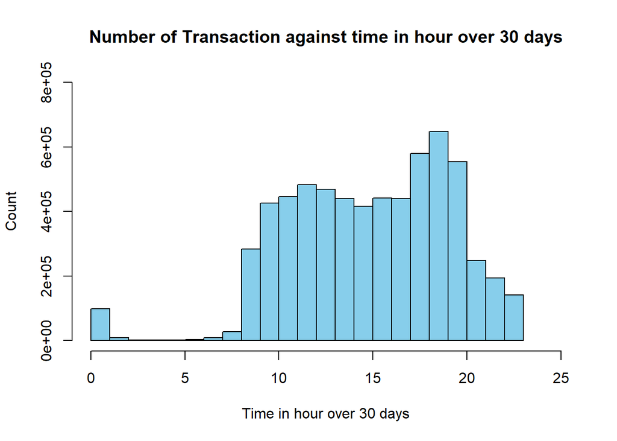

```r
dataset$hour <- mod(dataset$step, 24)

hist(dataset$hour,
     main="Number of Transaction against time in hour over 30 days",
     xlab="Time in hour over 30 days",
     ylab="Count",
     ylim=c(0,800000),
     xlim=c(0,25),
     col=c("skyblue"))
```

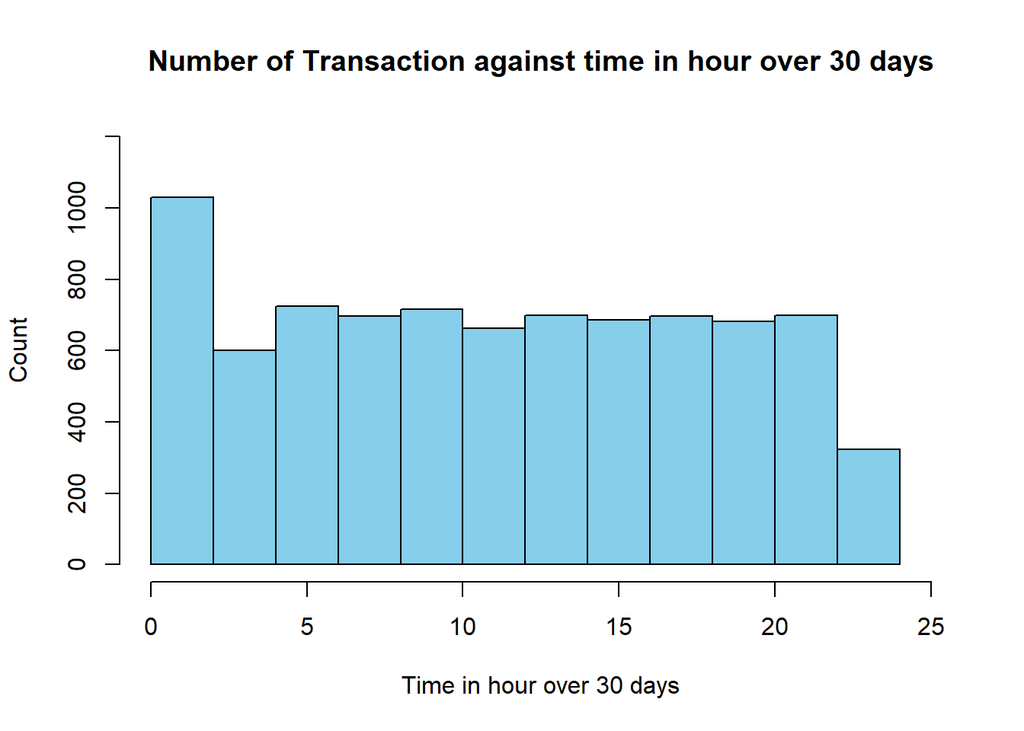

```r
hist(dataset$hour[dataset$isFraud==1],
     main="Number of Transaction against time in hour over 30 days",
     xlab="Time in hour over 30 days",
     ylab="Count",
     ylim=c(0,1200),
     xlim=c(0,25),
     col=c("skyblue"))
```

Unsurprisingly, many of the transactions happen between the hours of 08:00 and 23:00, when people are most likely to be awake. Comparing that to fraudulent transactions, we see the same uniform distribution, with a spike at 00:00.

It is also useful to observe correlation between the data

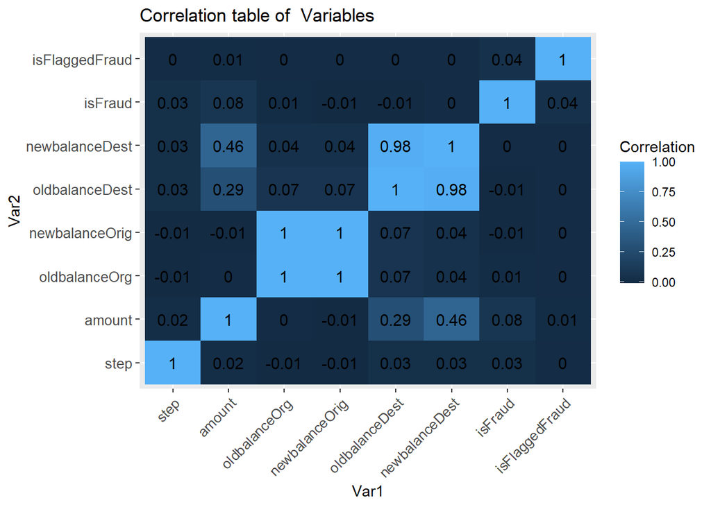

```r
numdata <- dataset[,c(1,3,5,6,8,9,10,11)]
corr_mat <- round(cor(numdata, use = "pairwise.complete.obs"), 2)

melted_corr_mat <- as.data.frame(as.table(corr_mat))
names(melted_corr_mat) <- c("Var1","Var2","value")

ggplot(data = melted_corr_mat, aes(x=Var1, y=Var2,fill=value)) + labs(title = "Correlation table of  Variables", fill = "Correlation") + geom_tile() + theme(axis.text.x = element_text(angle = 45, hjust = 1, size = 10), axis.text.y = element_text(size = 10)) +geom_text(aes(Var2, Var1, label = value),color = "black", size = 4)
```

We can now move on to using logistic regression on this data set. We will use concepts and code snippets from https://www.r-bloggers.com/2019/11/logistic-regression-in-r-a-classification-technique-to-predict-credit-card-default/ and https://www.kaggle.com/code/mahmoud86/logistic-regression-simulation.

When running this code initially, the vast number of observations made it too computationally expensive to run the logistic regression on the entire data set, hence we have limited the observations so the code can be ran in a timely manner. This will make it so the results will lose some accuracy, but is needed for the computational aspect of this assessment all whilst still allowing us to make valuable inferences.

```r
test_data<-dataset[,c("isFraud","step","amount","oldbalanceOrg","newbalanceOrig","oldbalanceDest","newbalanceDest","isFlaggedFraud")]
test_data$isFraud<-as.factor(test_data$isFraud)
test_data$isFlaggedFraud<-as.factor(test_data$isFlaggedFraud)
set.seed (2)
sample_rows <- sample(nrow(test_data), 600000)
sampled_test_data <- test_data[sample_rows, ]
```

```r
set.seed(2)
index <- sample(2, nrow(sampled_test_data), replace = TRUE, prob = c(0.7, 0.3))
train <- sampled_test_data[index == 1, ]
test  <- sampled_test_data[index == 2, ]
```

```r
dim(train)
```

```
## [1] 419468      8
```

```r
dim(test)
```

```
## [1] 180532      8
```

We can see the 70/30 split from this quite confidently. We will now create a logistic regression model using the glm command.

```r
glm.fit <- glm(isFraud ~ ., data = sampled_test_data, family = binomial)
summary(glm.fit)
```

```
##
## Call:
## glm(formula = isFraud ~ ., family = binomial, data = sampled_test_data)
##
## Deviance Residuals:
##    Min      1Q  Median      3Q     Max
##  -8.49    0.00    0.00    0.00    8.49
##
## Coefficients:
##                   Estimate Std. Error    z value Pr(>|z|)
## (Intercept)     -3.220e+14  1.762e+05 -1.828e+09   <2e-16 ***
## step             1.557e+11  6.089e+02  2.557e+08   <2e-16 ***
## amount          -4.335e+07  2.807e-01 -1.545e+08   <2e-16 ***
## oldbalanceOrg    5.735e+08  6.131e-01  9.353e+08   <2e-16 ***
## newbalanceOrig  -9.278e+08  6.063e-01 -1.530e+09   <2e-16 ***
## oldbalanceDest   1.512e+07  2.155e-01  7.018e+07   <2e-16 ***
## newbalanceDest  -2.539e+07  2.143e-01 -1.185e+08   <2e-16 ***
## isFlaggedFraud1  5.352e+15  3.877e+07  1.380e+08   <2e-16 ***
## ---
## Signif. codes:  0 '***' 0.001 '**' 0.01 '*' 0.05 '.' 0.1 ' ' 1
##
## (Dispersion parameter for binomial family taken to be 1)
##
##     Null deviance: 12151  on 599999  degrees of freedom
## Residual deviance: 37197  on 599992  degrees of freedom
## AIC: 37213
##
## Number of Fisher Scoring iterations: 25
```

Here we see that all the covariates are majorly significant to predicting whether a transaction is fraud or not, with an AIC = 37213. The AIC figure is of use for future comparisons of other models. We can use some evaluation techniques to see how accurate our model is, such as the confusion matrix.

```r
glm.probs = predict(glm.fit ,type ="response")
glm.pred=rep("0",1250)
glm.pred[glm.probs >.5]="1"
table(glm.pred,sampled_test_data$isFraud)
```

[output not shown]

We can then compute our accuracy using a simple formula.

```r
accuracy <- table(glm.pred, sampled_test_data$isFraud)
sum(diag(accuracy))/sum(accuracy)
```

```
## [1] 0.9369628
```

What we are seeing is that the values on the diagonal of the confusion matrix are “correct” predictions, whilst the off diagonal elements are “incorrect” predictions. We see then that our model has an accuracy of 93%. Since we are using a synthetic data set, this number could be attributed to the fact that the data is inherently “nice” for that purpose. Even so, the logistic regression model does seem to fit our data quite well. For future work, we could implement more machine learning techniques such as random forest, xgboost etc. and then evaluate using methods such as AUC/ROC.

References: https://www.kaggle.com/code/alicenyms/eda-and-imbalanced-dataset-techniques https://www.kaggle.com/code/xiaoyuezhou/eda-on-dataset-for-fraud-detection https://www.r-bloggers.com/2019/11/logistic-regression-in-r-a-classification-technique-to-predict-credit-card-default/ https://www2.cs.uregina.ca/~dbd/cs831/notes/confusion_matrix/confusion_matrix.html https://r4ds.hadley.nz/